# Homework 2

Begüm Tüzüner

2022-05-07

## Introduction

In this homework, a linear regression model will be conducted based on the provided data by the instructor which contains gasoline and diesel sales (in 1000 m3) of a major distributor between 2000 and 2007, and a number of potential independent variables. These variables are summarized as follows:

UGS: Unleaded gasoline sale in a given quarter, RNUV: An index indicating the rate of new unleaded gasoline using vehicles being added to the traffic in a quarter, PU: Average price (adjusted with an index) of a liter of unleaded gasoline in a quarter, PG: Average price (adjusted with an index) of a liter of diesel gasoline in a quarter, NUGV: Number of unleaded gasoline using vehicles in the traffic, NDGV: Number of diesel gasoline using vehicles in the traffic (per 1000 people), GNPA: Agriculture component of Gross National Product (adjusted with an index), GNPC: Commerce component of Gross National Product (adjusted with an index), GNP: Grand total for GNP (agriculture, commerce and other components total).

The ultimate aim is to predict UGS (Unleaded Gasoline Sale) for missing 4 Quarters in 2007. To do that, seasonality, lags and trend in data should be considered.

## Approach

Before starting to the model, small manipulations on excel file has been made such as eliminating the spaces between numbers to prevent to be read as characters, reorganizing Quarter column and etc. To begin with, to see more clearly, UGS as a time series function and auto-correlated function of UGS will be plotted.

```r
hw2 <- read_csv("C:/Users/btuzuner/Downloads/IE360_Spring22_HW2_data.csv")
```

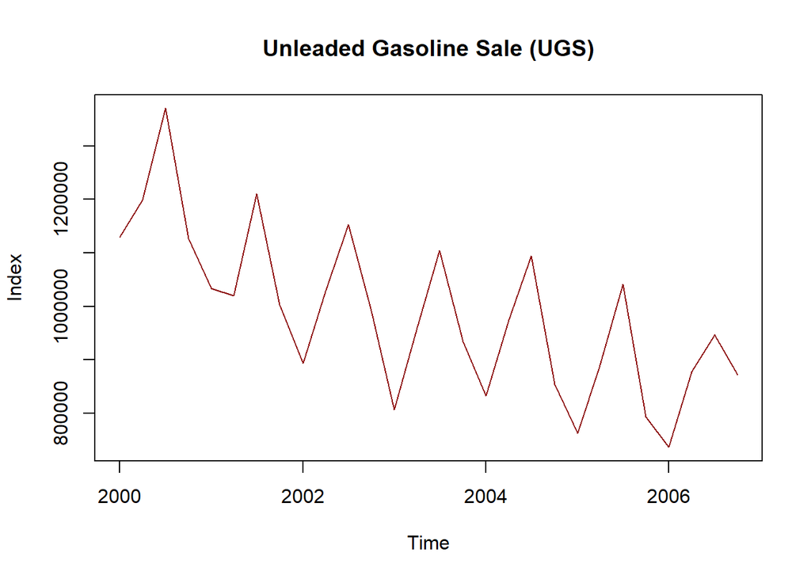

```r
hw2$Quarter <- as.Date(parse_date_time(hw2$Quarter ,"Ym"),
                             format = "%Y-%m")
plot(hw2$Quarter, hw2$UGS, type = "l",
     xlab = "Time",
     ylab = "Index",main = "Unleaded Gasoline Sale (UGS)",col="darkred")
```

As seen above, UGS has a decreasing trend with seasonality. Also, there is no evidence to proof this function has white-noise property. Just the opposite, there is non-zero mean with non-constant variance.

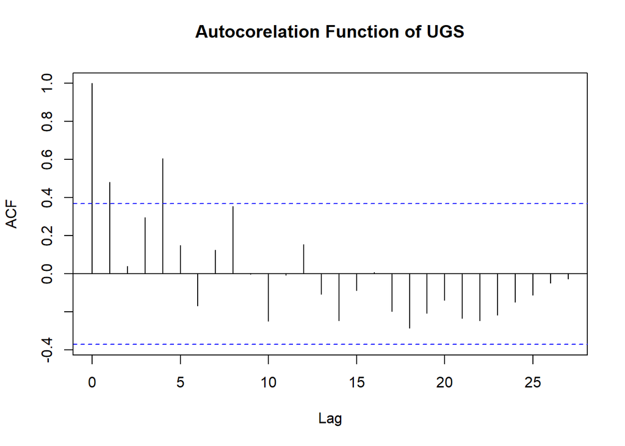

```r
acf_ugs <- acf(hw2$UGS,28, plot = FALSE)
plot(acf_ugs, main = "Autocorelation Function of UGS")
```

```r
lag1 <- c(0, hw2$UGS)
hw2 <- cbind(hw2,lag1=lag1[1:28])
hw2 <- hw2 %>% replace_with_na(replace = list(lag1 = 0))
head(hw2)
```

```
##      Quarter     UGS   RNUV # LPG Vehicles (NLPG)
## 1 2000-01-01 1128971 0.0146                940000
## 2 2000-04-01 1199569 0.0205                941000
## 3 2000-07-01 1370167 0.0207                943500
## 4 2000-10-01 1127548 0.0163                948000
## 5 2001-01-01 1033918 0.0071                950000
## 6 2001-04-01 1019754 0.0051                955000
##   Price of Unleaded Gasoline (PU) Price of Diesel Gasoline (PG)
## 1                          469.03                        355.69
## 2                          459.42                        344.58
## 3                          439.98                        327.21
## 4                          402.08                        300.67
## 5                          411.58                        305.75
## 6                          520.39                        374.78
##   # Unleaded Gasoline Vehicles (NUGV) # of Diesel Gasoline Vehicles (NDGV)
## 1                             4647500                             281.9853
## 2                             4742876                             284.0813
## 3                             4840931                             286.7169
## 4                             4919685                             288.3137
## 5                             4954754                             287.6237
## 6                             4980204                             287.8814
##   GNP Agriculture GNP Commerce GNP Total    lag1
## 1         1040173      3483132  18022686      NA
## 2         1760460      4525451  21797130 1128971
## 3         6974808      5915204  30050207 1199569
## 4         3267125      4929778  24480153 1370167
## 5         1004528      3418387  15832648 1127548
## 6         1449357      4359831  20296918 1033918
```

```r
hw2 <- data.table(hw2)
hw2[, lag4:= shift(UGS,4)]

d_UGS <- ts(hw2$UGS, frequency = 4, start= c(2000,1))
dec <- decompose(d_UGS, type = "additive")



fit1 <- lm(UGS~
             dec$trend +dec$seasonal
           # + lag4
           # + hw2$`Price of Unleaded Gasoline (PU)`
           # +hw2$`Price of Diesel Gasoline (PG)`
           # +hw2$`GNP Agriculture`
            # +hw2$`# LPG Vehicles (NLPG)`
           # +hw2$`# of Diesel Gasoline Vehicles (NDGV)`
           # +hw2$`# Unleaded Gasoline Vehicles (NUGV)`
           , data = hw2)
summary(fit1)
```

```
##
## Call:
## lm(formula = UGS ~ dec$trend + dec$seasonal, data = hw2)
##
## Residuals:
##    Min     1Q Median     3Q    Max
## -65539  -8153   2015  11544  41149
##
## Coefficients:
##                Estimate Std. Error t value Pr(>|t|)
## (Intercept)  -4.546e+03  5.464e+04  -0.083    0.934
## dec$trend     1.006e+00  5.562e-02  18.079 2.80e-14 ***
## dec$seasonal  9.994e-01  4.972e-02  20.101 3.39e-15 ***
## ---
## Signif. codes:  0 '***' 0.001 '**' 0.01 '*' 0.05 '.' 0.1 ' ' 1
##
## Residual standard error: 25170 on 21 degrees of freedom
##   (4 observations deleted due to missingness)
## Multiple R-squared:  0.9751, Adjusted R-squared:  0.9727
## F-statistic: 411.1 on 2 and 21 DF,  p-value: < 2.2e-16
```

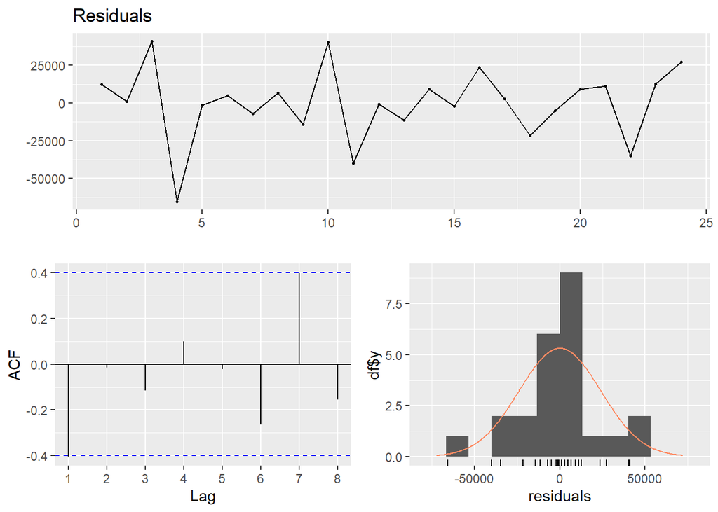

```
##
##  Breusch-Godfrey test for serial correlation of order up to 6
##
## data:  Residuals
## LM test = 12.308, df = 6, p-value = 0.05545
```

```r
checkresiduals(fit1)
```

The code above creates the seasonality (quarters) and trend of UGS via decompose() function. Also, lag1 and lag4 are created to use in the model. As we can see, the linear model for trend and seasonality works quite well. Both variables are significant and Multiple and Adjusted R squared values are close to 1. So, let’s add lagged variables to this model.

The next step is to determine which independent variables will be used. For this purpose, correlation matrix of the data set is created. Before the correlation matrix, the Quarter variable and lagged variables attached to data set will be eliminated with a small manipulation.

```r
hw2_no_lag <- read_csv("C:/Users/btuzuner/Downloads/IE360_Spring22_HW2_data.csv")
```

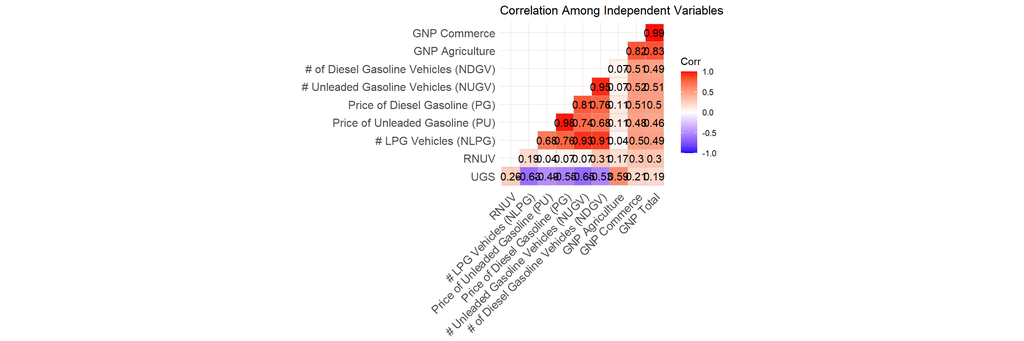

```r
hw2_no_lag <- select(hw2_no_lag, -1)
ggcorrplot(cor(hw2_no_lag),
           type = "lower",
           lab = TRUE,
           title = "Correlation Among Independent Variables")
```

```r
fit2 <- lm(UGS~
             dec$trend +dec$seasonal
            + lag4
             +hw2$`# LPG Vehicles (NLPG)`
           , data = hw2)
summary(fit2)
```

```
##
## Call:
## lm(formula = UGS ~ dec$trend + dec$seasonal + lag4 + hw2$`# LPG Vehicles (NLPG)`,
##     data = hw2)
##
## Residuals:
##    Min     1Q Median     3Q    Max
## -64478  -7698   4258   9493  46768
##
## Coefficients:
##                               Estimate Std. Error t value Pr(>|t|)
## (Intercept)                 -1.109e+05  2.557e+05  -0.434  0.67001
## dec$trend                    1.069e+00  2.740e-01   3.902  0.00115 **
## dec$seasonal                 9.900e-01  1.543e-01   6.416  6.4e-06 ***
## lag4                         5.698e-03  1.435e-01   0.040  0.96879
## hw2$`# LPG Vehicles (NLPG)`  3.115e-02  5.645e-02   0.552  0.58828
## ---
## Signif. codes:  0 '***' 0.001 '**' 0.01 '*' 0.05 '.' 0.1 ' ' 1
##
## Residual standard error: 27440 on 17 degrees of freedom
##   (6 observations deleted due to missingness)
## Multiple R-squared:  0.963,  Adjusted R-squared:  0.9543
## F-statistic: 110.6 on 4 and 17 DF,  p-value: 6.224e-12
```

For that purpose, it will be focused on the correlation among the random part of decompose() function and other independent variables.

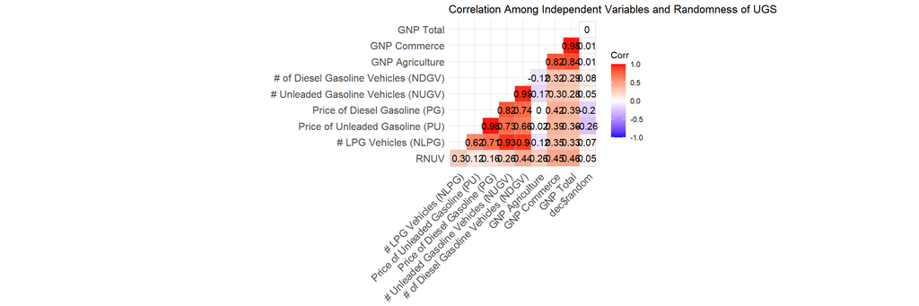

```r
random <- cbind(hw2_no_lag, dec$random)
random <- select(random,-1)
random <- random %>% slice(-c(1,2, 27, 28))
ggcorrplot(cor(random),
           type = "lower",
           lab = TRUE) +
           labs(title = "Correlation Among Independent Variables and Randomness of UGS")
```

The maximum absolute value between random part of UGS and independent variables is for PU and PG. So, they are selected top be add in the model.

```r
fit3 <- lm(UGS~
             dec$trend +dec$seasonal
            + lag4
            + hw2$`Price of Unleaded Gasoline (PU)`
            +hw2$`Price of Diesel Gasoline (PG)`
           , data = hw2)
summary(fit3)
```

```
##
## Call:
## lm(formula = UGS ~ dec$trend + dec$seasonal + lag4 + hw2$`Price of Unleaded Gasoline (PU)` +
##     hw2$`Price of Diesel Gasoline (PG)`, data = hw2)
##
## Residuals:
##    Min     1Q Median     3Q    Max
## -39016 -14528   1901  13190  44025
##
## Coefficients:
##                                         Estimate Std. Error t value Pr(>|t|)
## (Intercept)                            4.139e+05  2.594e+05   1.595   0.1302
## dec$trend                              6.065e-01  2.823e-01   2.149   0.0473
## dec$seasonal                           8.662e-01  1.483e-01   5.842  2.5e-05
## lag4                                   1.712e-01  1.486e-01   1.152   0.2661
## hw2$`Price of Unleaded Gasoline (PU)` -6.381e+02  7.238e+02  -0.882   0.3910
## hw2$`Price of Diesel Gasoline (PG)`    3.037e+02  9.757e+02   0.311   0.7596
##
## (Intercept)
## dec$trend                             *
## dec$seasonal                          ***
## lag4
## hw2$`Price of Unleaded Gasoline (PU)`
## hw2$`Price of Diesel Gasoline (PG)`
## ---
## Signif. codes:  0 '***' 0.001 '**' 0.01 '*' 0.05 '.' 0.1 ' ' 1
##
## Residual standard error: 24790 on 16 degrees of freedom
##   (6 observations deleted due to missingness)
## Multiple R-squared:  0.9716, Adjusted R-squared:  0.9627
## F-statistic: 109.3 on 5 and 16 DF,  p-value: 8.712e-12
```

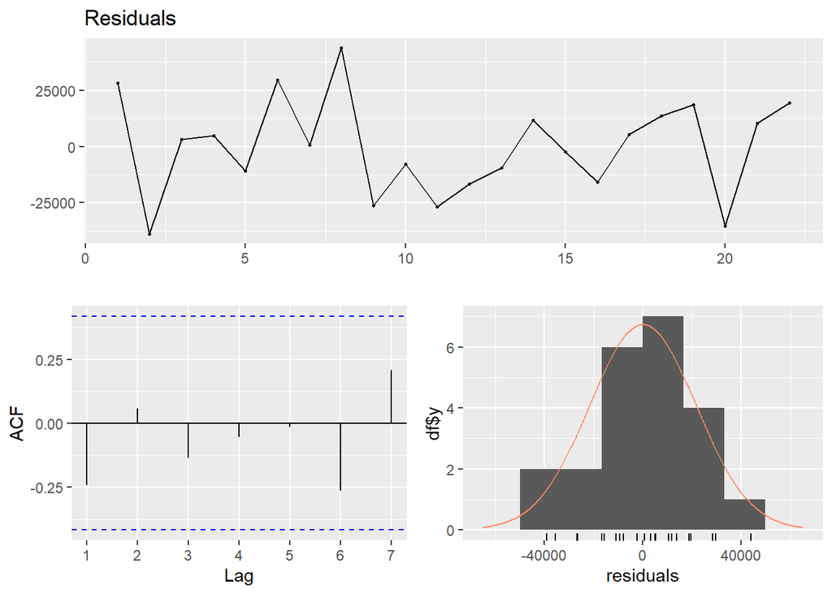

```
##
##  Breusch-Godfrey test for serial correlation of order up to 9
##
## data:  Residuals
## LM test = 11.564, df = 9, p-value = 0.239
```

```r
checkresiduals(fit3)
```

```r
trend = seq(32,5,by=-1)
quarter=seq(1,4,by=1)
hw2_factor = cbind(hw2,quarter)
hw2_factor = cbind(hw2_factor,trend)

fit_factor <- lm(UGS~
             trend + as.factor(quarter)
             +hw2_factor$`# LPG Vehicles (NLPG)`
           , data = hw2_factor)
summary(fit_factor)
```

```
##
## Call:
## lm(formula = UGS ~ trend + as.factor(quarter) + hw2_factor$`# LPG Vehicles (NLPG)`,
##     data = hw2_factor)
##
## Residuals:
##    Min     1Q Median     3Q    Max
## -83022 -23287   3235  18555  90847
##
## Coefficients:
##                                     Estimate Std. Error t value Pr(>|t|)
## (Intercept)                        8.956e+03  1.724e+05   0.052 0.959046
## trend                              2.422e+04  3.163e+03   7.657 1.21e-07 ***
## as.factor(quarter)2                1.286e+05  2.128e+04   6.044 4.40e-06 ***
## as.factor(quarter)3                2.824e+05  2.140e+04  13.200 6.24e-12 ***
## as.factor(quarter)4                9.835e+04  2.137e+04   4.601 0.000139 ***
## hw2_factor$`# LPG Vehicles (NLPG)` 3.259e-01  9.184e-02   3.549 0.001800 **
## ---
## Signif. codes:  0 '***' 0.001 '**' 0.01 '*' 0.05 '.' 0.1 ' ' 1
##
## Residual standard error: 39600 on 22 degrees of freedom
## Multiple R-squared:  0.944,  Adjusted R-squared:  0.9313
## F-statistic: 74.15 on 5 and 22 DF,  p-value: 5.077e-13
```

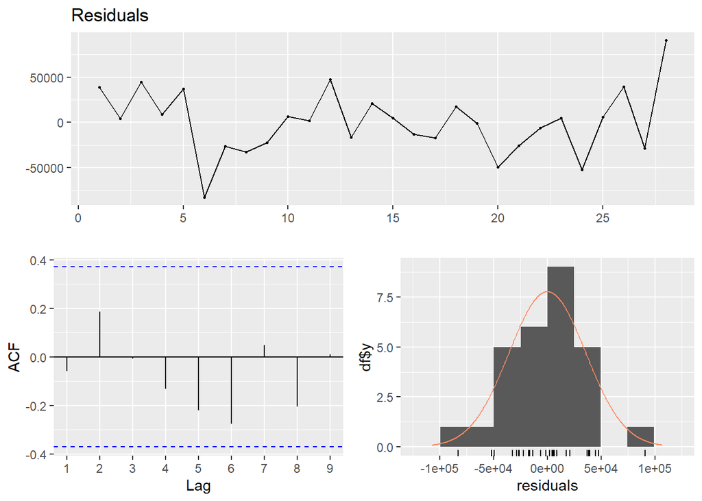

```
##
##  Breusch-Godfrey test for serial correlation of order up to 9
##
## data:  Residuals
## LM test = 13.521, df = 9, p-value = 0.1404
```

```r
checkresiduals(fit_factor)
```

Thus, all the variables are significant now. Multiple and Adjusted R squared values are well and ACF seems better since there is no lag. Residuals are closer to normal distribution than the previous model. If more independent variables are added in the model, the added variables are not significant as seen above. The reason behind that could be high correlation between the independent variables. Effect of the second independent variable cannot be considered reasonable by the model due to that reason.

```r
error = hw2$UGS - predict(fit_factor)
n=length(hw2$UGS)

mean=mean(hw2$UGS)
sd=sd(hw2$UGS)
bias = sum(error)/sum(hw2$UGS)
mape = sum(abs(error/hw2$UGS))/length(hw2$UGS)
mad = sum(abs(error))/length(hw2$UGS)
wmape = mad/mean
print(data.frame(BIAS = bias,MAPE =  mape, MAD = mad,WMAPE = wmape))
```

```
##            BIAS       MAPE      MAD      WMAPE
## 1 -3.748276e-16 0.02815117 26757.28 0.02710388
```

Bias is really small and also other error terms are quite well. This means, it can be proceeded with this model.

## Prediction

Now, it is time to predict missing 4 quarters in 2007. The last model with statistical analysis will be used for prediction to see if its plot is how much close to the actual plot.

This time, the original excel file will be reread for gathering all the unmanipulated data.

```r
hw2_na <- read_csv("C:/Users/btuzuner/Downloads/IE360_Spring22_HW2_data (1).csv")
hw2_na$Quarter <- as.Date(parse_date_time(hw2_na$Quarter ,"Ym"),
                             format = "%Y-%m")
hw2_na <- data.table(hw2_na)
setnames(x= hw2_na, old= "Unleaded Gasoline Sale (UGS)", new = "UGS")

trend = seq(32,1,by=-1)
quarter=seq(1,4,by=1)
hw2_na = cbind(hw2_na,quarter)
hw2_na = cbind(hw2_na,trend)


fit_factor1 <- lm(UGS~
             trend + as.factor(quarter)
             + hw2_na$`# LPG Vehicles (NLPG)`
           , data = hw2_na, na.rm=TRUE )
predictf <- predict(object=fit_factor1,newdata = hw2_na)
print(data.frame(predictf[29:32]))
```

```
##    predictf.29.32.
## 29        664776.7
## 30        772560.4
## 31        910520.7
## 32        717322.3
```

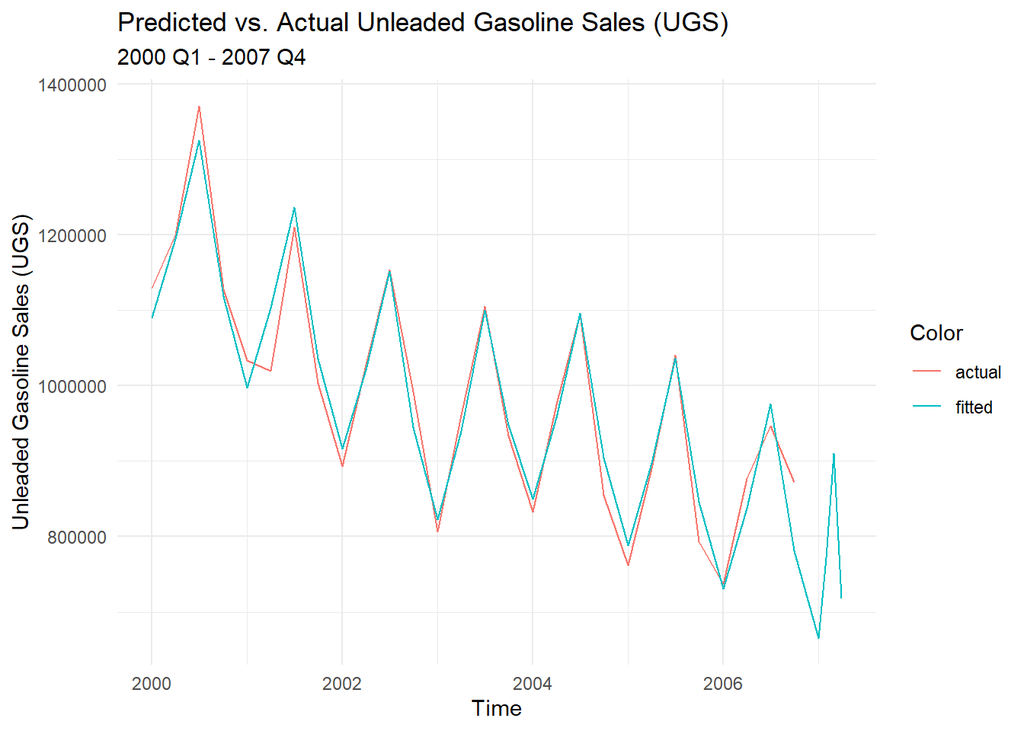

```r
hw2_na <- cbind(hw2_na, predictf)
hw2_na$Quarter <- as.Date(hw2_na$Quarter)

ggplot() +
  geom_line(data = hw2_na, aes(x = Quarter, y = UGS ,color = "actual")) +
  geom_line(data = hw2_na, aes(x = Quarter, y = predictf ,color = "fitted")) +
  labs(title = "Predicted vs. Actual Unleaded Gasoline Sales (UGS)",
    subtitle = "2000 Q1 - 2007 Q4",
    x = "Time",
    y = "Unleaded Gasoline Sales (UGS)",
    color = "Color") +
  theme_minimal()
```

## Conclusion

In this homework, it can be easily seen that adding more variables may not always be a good method for fit. The possible options should be tested and than the model should be established.